# Unit 5 Data Wrangling 作業總評

2021/10/26

> 總評初稿，傳送個人回饋單之後更新。

## 作業評分總原則

這個部分是總原則說明，讓同學了解教練與助教評分的方式。單元5 學習使用`dplyr`的函式整頓資料，善用這些函式能構成完整的描述統計報告。Rmarkdown的編輯指引可參考[速查表](https://rstat-project.github.io/Reproducible_STAT/cheatsheets/rmarkdown-2.0-TC.pdf)，提供需要指引的同學隨時參考。

### 準時推送(OT)

本次截止日期時間是2021/10/25 14:00:00。教練寫了R code，檢測各位同學的作業repo裡有沒有Assignment.html？Assignment.html的日期時間有沒有超過繳交期限？如果有Assignment.html且未逾時，OT評分就是“非常厲害”；如果過了繳交期限，從這個單元開始，OT評分就是“需要加把勁”，過了下一次上課開始時間，就沒有評分了。

### 演練活用度(EO)

EO評分以點數計算，計算方式目前有以下幾種：

- 回覆討論區的單元討論貼文

以下是出現在討論區，每個單元討論貼文的固定置頂內容。

```
歡迎分享你學習這個單元時發現的問題 (😄)
還有你認為有助學習這個單元的任何資訊或技巧 (🎉)
留意上課會出現意外的限量搶答(👍)

教練給予以上任何一種表情符號，均列入演練活用度評分。
```

由於表情符號是unicode字符的一種，教練能直接運用網頁搜尋計算次數，獲得任何一種表情符號，計一次EO點數。

作業演練項目有標記**活用**的項目，請將成果回覆到單元討論區帖子，方便教練和助教清點。

- 分享運用心得

在討論區以“💡Ideas”張貼心得文，說明使用那些單元的技巧或觀念解決問題。

- 分享學習問題

在討論區以“🙏Q&A”張貼問題，說明你遇到的技巧或觀念問題。回覆者的回答有助解決問題，可獲得🎉 。

不論是那種狀況，一個單元每位同學可獲得的EO點數上限是4點。複數單元的心得或學習問題，請自行指定要計入那個單元作業評分。

## 單元5學習重點與建議

單元5的主要演練項目分別針對`dplyr`整頓資料及描述統計的常用函式，同時透過`filter()`演練邏輯運算子的運用方式。只要用心紀錄每項演練心得，這份作業會成為之後你使用這些函式及邏輯運算子的任何場合，第一份可用的參考資料。

```
## 完整程式碼請見個人回饋單
```

## 作業繳交狀況

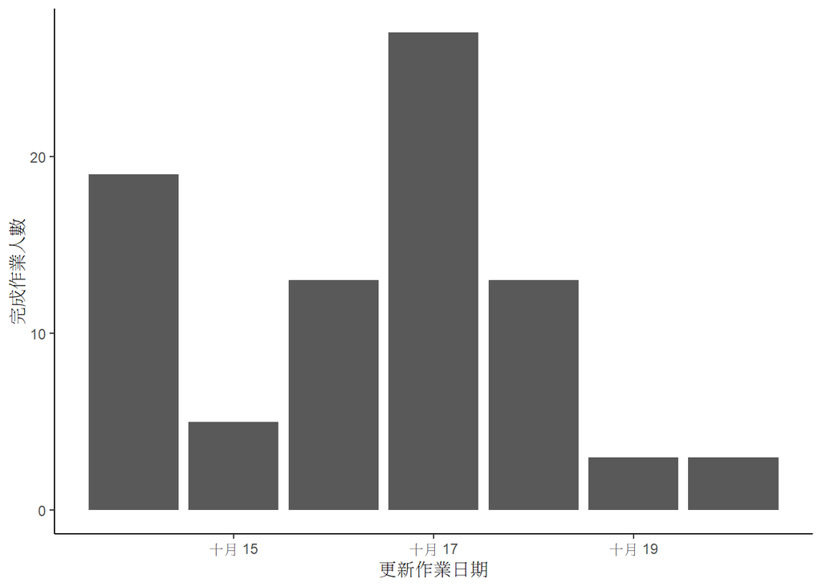

## 檢視個人回饋單

有收到個人評語的同學，只要以瀏覽器開啟feedback.html，就能看到教練和組教給的評語。